# Taller 1 - Análisis Avanzado de Datos

Cristhian Zamora

El conjunto de datos taller1.txt contiene la información del perfíl genómico de un conjunto de 1200 líıneas celulares. Para estas se busca determinar cuáles de los 5000 genes (ubicados en cada columna) son de relevancia para la predicción de la variable respuesta (efectividad del tratamiento anticancer, medida como variable continua). Responda las siguientes preguntas:

1. ¿Hay multicolinealidad en los datos? Explique sucintamente.

En el caso de regresión lineal, no es posible ajustar un modelo dado que los datos de modelado tienen más variables que registros, lo que hace que la matriz diseño no tenga rango completo, la matriz diseño contiene todas las variables explicativas para cada una de las observaciones en los datos, al no tener rango completo algunas de las columnas son linealmente dependientes de otras, lo que puede interpretarse como multicolinealidad, lo que conlleva que la matriz sea no invertible y su vez esto provoca que las solución por mínimos cuadrados ordinarios no se pueda calcular.

Adicional a lo anterior, al calcular la matriz de correlaciones:

```r
datos <- data.frame(read_csv('taller1.txt', show_col_types = FALSE))
```

Se observa que en los datos no existe un par de variables que presente una correlación mayor al 70%. Esto significa que no hay evidencia de que las variables en los datos estén altamente correlacionadas entre sí, lo que sugiere que no hay multicolinealidad en los datos.

```r
corelacion <- datos %>%
  as.matrix %>%
  cor %>%
  as.data.frame %>%
  rownames_to_column(var = 'var1') %>%
  gather(var2, value, -var1)

filter(corelacion, abs(value) > .7 & var1!=var2)
```

| var1 | var2 | value |
| --- | --- | --- |

2. Separe aleatoriamente (pero guarde la semilla) su conjunto de datos en dos partes:
- Entrenamiento: 1000 líıneas celulares
- Prueba: 200 líneas celulares.

Se establece la semilla 123 para hacer la separación reproducible, parra el total de observaciones se genera un vector de índices aleatorios, después se seleccionan los primeros mil índices a entrenamiento y los restantes a pruebas.

```r
# Establecer la semilla para hacer la separación reproducible
set.seed(123)

# Obtener el número de filas en los datos
num_filas <- nrow(datos)

# Generar un vector de índices aleatorios
indices_aleatorios <- sample(1:num_filas, num_filas)

# Seleccionar las primeras 1000 filas para entrenamiento
datos_entrenamiento <- datos[indices_aleatorios[1:1000],]

# Seleccionar las siguientes 200 filas para prueba
datos_prueba <- datos[indices_aleatorios[1001:1200],]
```

Usando el paquete glmnet se evalúa una serie de valores lambda usando una validación cruzada para Ridge y Lasso, por ultimo se obtienen los valores de lambda que minimizan el error cuadrático medio (ECM)

```r
# Cargar el paquete glmnet
library(Matrix)
library(glmnet)
# Convertir los datos de entrenamiento en una matriz
X <- as.matrix(datos_entrenamiento[,-1])
y <- datos_entrenamiento[,1]

# Definir una secuencia de valores de lambda
lambda_seq <- 10^seq(10, -2, length=100)

# Realizar la validación cruzada para Ridge y Lasso
cv.ridge <- cv.glmnet(X, y, alpha=0, lambda=lambda_seq, type.measure="mse")
cv.lasso <- cv.glmnet(X, y, alpha=1, lambda=lambda_seq, type.measure="mse")

# Obtener los valores de lambda que minimizan el error cuadrático medio (ECM)
lambda_r <- cv.ridge$lambda.min
lambda_l <- cv.lasso$lambda.min

cat("El valor óptimo de lambda para la regresión ridge es", lambda_r, "\n")
```

```
## El valor óptimo de lambda para la regresión ridge es 0.01
```

```r
cat("El valor óptimo de lambda para la regresión lasso es", lambda_l, "\n")
```

```
## El valor óptimo de lambda para la regresión lasso es 0.07054802
```

4. Ajuste la regresión ridge y lasso con los valores estimados de λr y λl obtenidos en (3) usando los 1000 datos de entrenamiento.

Usando los valores óptimos de lambda para Ridge y Lasso respectivamente, se ajustan las regresiones para la partición de entrenamiento.

```r
# Regresión ridge
ridge_model <- glmnet(X , y, alpha = 0, lambda = lambda_r)

# Regresión lasso
lasso_model <- glmnet(X , y, alpha = 1, lambda = lambda_l)
```

Para los mejores modelos Ridge y Lasso hallados, se realiza el evaluación sobre los datos de la partición de prueba. Se calcula el Error cuadrático medio como métrica de rendimiento del modelo para cada uno de los métodos de regresión, y por ultimo se determina que método presenta un mejor desempeño.

```r
# Convertir los datos de prueba en una matriz
X_test <- as.matrix(datos_prueba[,-1])
y_test <- datos_prueba[,1]
```

```r
# ECM de la regresión ridge
ridge_pred <- predict(ridge_model, newx = X_test)
ridge_ecm <- mean((ridge_pred - y_test)^2)

# ECM de la regresión lasso
lasso_pred <- predict(lasso_model, newx = X_test)
lasso_ecm <- mean((lasso_pred - y_test)^2)
```

```r
if (ridge_ecm < lasso_ecm) {
  cat("El modelo de regresión ridge es más apropiado para propósitos de predicción.")
} else if (lasso_ecm < ridge_ecm) {
  cat("El modelo de regresión lasso es más apropiado para propósitos de predicción.")
} else {
  cat("Ambos modelos tienen el mismo ECM y son igualmente apropiados para propósitos de predicción.")
}
```

```
## El modelo de regresión lasso es más apropiado para propósitos de predicción.
```

6. Ajuste el modelo seleccionado en (5) para los 1200 datos. Note que en este punto ya tiene un λ estimado y un modelo seleccionado.

Habiendo hallado el método de regresión que mejor se ajusta a los datos, se usa la totalidad de los datos disponibles para reentrenar dicho modelo.

```r
# Convertir los datos totales en una matriz
X_tot <- as.matrix(datos[,-1])
y_tot <- datos[,1]
```

```r
lasso_model_tot <- glmnet(X_tot , y_tot, alpha = 1, lambda = lambda_l)
```

7. Grafique las trazas de los coeficientes en función de la penalización para el modelo ajustado en (6).

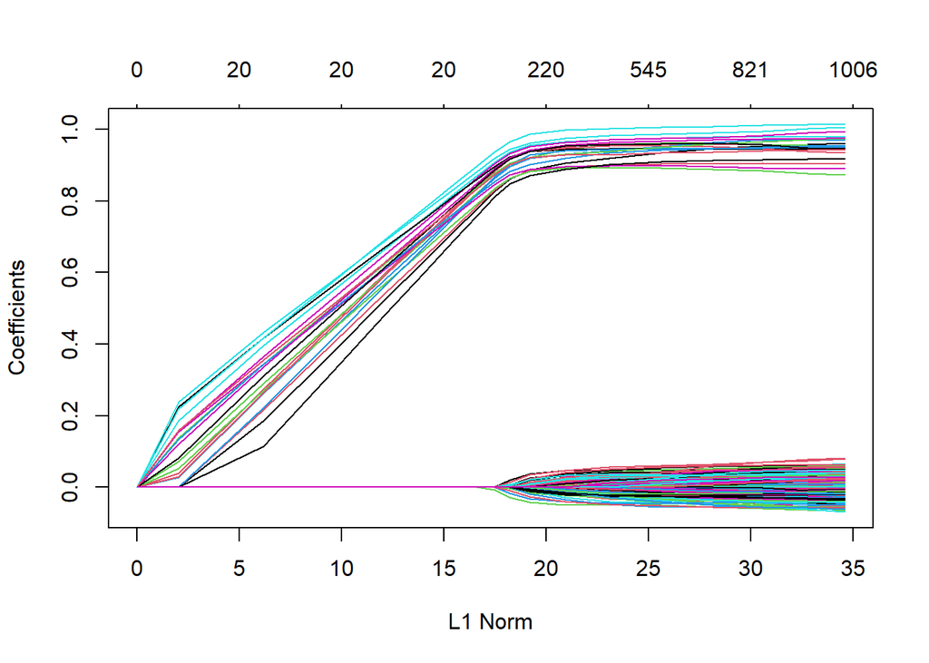

```r
lasso_model_tot_ <- glmnet(X_tot , y_tot, alpha = 1, lambda = lambda_seq)
plot(lasso_model_tot_)
```

8. En un párrafo resuma los resultados obtenidos dado el objetivo inicial del estudio.

```r
coef_seq <- predict(lasso_model_tot, newx = X_tot, type="coefficients")
coef_df = as.data.frame(as.matrix(coef_seq))
coef_df <- coef_df %>% arrange(desc(abs(s0)))
head(coef_df, 10)
```

|  | s0 |
| --- | --- |
| V17 | 0.9857457 |
| V11 | 0.9614091 |
| V5 | 0.9551121 |
| V6 | 0.9516272 |
| V18 | 0.9428274 |
| V2 | 0.9423126 |
| V7 | 0.9390348 |
| V19 | 0.9383421 |
| V14 | 0.9382871 |
| V10 | 0.9278384 |

Una primera conclusión es que, debido a la naturaleza del conjunto de datos, el cual cuenta con mas variables que observaciones, no es posible aplicar una regresión lineal por lo que es necesario explorar métodos robustos ante la multicolinealidad tales como la regresiones de Lasso y Ridge. En segundo lugar, se puede mencionar que, al evaluar los métodos de regresión de Ridge y Lasso, se encontró que el modelo de regresión más apropiado para el problema es la regresión Lasso. Por último, al analizar la magnitud de los coeficientes resultado de la regresión Lasso podemos decir que los cinco genes que mayor relevancia tienen para la predicción de la variable respuesta son los correspondientes a las columnas V17, V11, V5, V6 y V18.